# STAT 561 - Homework 2

Due: April 14, 2025

## Introduction

In this homework, we tackle the challenge of absenteeism in today’s dynamic work environment using logistic regression. We aim to predict and understand the patterns of absenteeism using a detailed dataset from a courier company in Brazil. Additionally, we analyze flu shot data to understand factors influencing flu vaccination uptake.

## Absenteeism Data Analysis

### Question 1: Exploratory Data Analysis (EDA)

#### Explanation

Exploratory Data Analysis (EDA) involves summarizing the main characteristics of a dataset by using visual methods. This step is crucial to understand the structure of the data, identify patterns, detect outliers, and check assumptions before performing further analysis.

#### Code

```r
# Load the dataset
absent <- read_excel("Absenteeism_at_work.xls")

# Recode absenteeism
absent <- absent %>%
  mutate(absenteeism = case_when(
    Absenteeism_time_in_hours >= 0 & Absenteeism_time_in_hours <= 20 ~ "Low",
    Absenteeism_time_in_hours > 20 & Absenteeism_time_in_hours <= 40 ~ "Moderate",
    Absenteeism_time_in_hours > 40 ~ "High"
  ))

# Convert categorical variables to factors
absent$absenteeism <- factor(absent$absenteeism)
absent$Month_of_absence <- factor(absent$Month_of_absence)
absent$Day_of_the_week <- factor(absent$Day_of_the_week)
absent$Seasons <- factor(absent$Seasons)
absent$Education <- factor(absent$Education)


# Check for missing values
missing_values <- sapply(absent, function(x) sum(is.na(x)))
print(missing_values)
```

```
##                              ID                Month_of_absence
##                               0                               0
##                 Day_of_the_week                         Seasons
##                               0                               0
##          Transportation_expense Distance_from_Residence_to_Work
##                               0                               0
##                    Service_time                             Age
##                               0                               0
##       Work_load_Average_in_days                       Education
##                               0                               0
##                             Son                             Pet
##                               0                               0
##                          Weight                          Height
##                               0                               0
##                 Body_mass_index       Absenteeism_time_in_hours
##                               0                               0
##                     absenteeism
##                               0
```

```r
# View the structure of the data
str(absent)
```

```
## tibble [740 × 17] (S3: tbl_df/tbl/data.frame)
##  $ ID                             : num [1:740] 11 36 3 7 11 3 10 20 14 1 ...
##  $ Month_of_absence               : Factor w/ 13 levels "0","1","2","3",..: 8 8 8 8 8 8 8 8 8 8 ...
##  $ Day_of_the_week                : Factor w/ 5 levels "2","3","4","5",..: 2 2 3 4 4 5 5 5 1 1 ...
##  $ Seasons                        : Factor w/ 4 levels "1","2","3","4": 1 1 1 1 1 1 1 1 1 1 ...
##  $ Transportation_expense         : num [1:740] 289 118 179 279 289 179 361 260 155 235 ...
##  $ Distance_from_Residence_to_Work: num [1:740] 36 13 51 5 36 51 52 50 12 11 ...
##  $ Service_time                   : num [1:740] 13 18 18 14 13 18 3 11 14 14 ...
##  $ Age                            : num [1:740] 33 50 38 39 33 38 28 36 34 37 ...
##  $ Work_load_Average_in_days      : num [1:740] 239554 239554 239554 239554 239554 ...
##  $ Education                      : Factor w/ 4 levels "1","2","3","4": 1 1 1 1 1 1 1 1 1 3 ...
##  $ Son                            : num [1:740] 2 1 0 2 2 0 1 4 2 1 ...
##  $ Pet                            : num [1:740] 1 0 0 0 1 0 4 0 0 1 ...
##  $ Weight                         : num [1:740] 90 98 89 68 90 89 80 65 95 88 ...
##  $ Height                         : num [1:740] 172 178 170 168 172 170 172 168 196 172 ...
##  $ Body_mass_index                : num [1:740] 30 31 31 24 30 31 27 23 25 29 ...
##  $ Absenteeism_time_in_hours      : num [1:740] 4 0 2 4 2 2 8 4 40 8 ...
##  $ absenteeism                    : Factor w/ 3 levels "High","Low","Moderate": 2 2 2 2 2 2 2 2 3 2 ...
```

```r
# Verify the column names
names(absent)
```

```
##  [1] "ID"                              "Month_of_absence"
##  [3] "Day_of_the_week"                 "Seasons"
##  [5] "Transportation_expense"          "Distance_from_Residence_to_Work"
##  [7] "Service_time"                    "Age"
##  [9] "Work_load_Average_in_days"       "Education"
## [11] "Son"                             "Pet"
## [13] "Weight"                          "Height"
## [15] "Body_mass_index"                 "Absenteeism_time_in_hours"
## [17] "absenteeism"
```

#### Observations for Question 1

```markdown
This section holds the interpretation of the question.
- The dataset contains various predictors such as month of absence, day of the week, seasons, and more.
- Absenteeism time has been recoded into three categories: Low, Moderate, and High.
- Categorical variables have been converted to factors for analysis.
- Missing values have been checked and reported.
```

### Question 2: Distribution of ‘Absenteeism time in hours’

#### Explanation

Understanding the distribution of a variable helps to identify its spread, central tendency, and the presence of any outliers. This information is crucial for selecting appropriate statistical methods for analysis.

#### Code

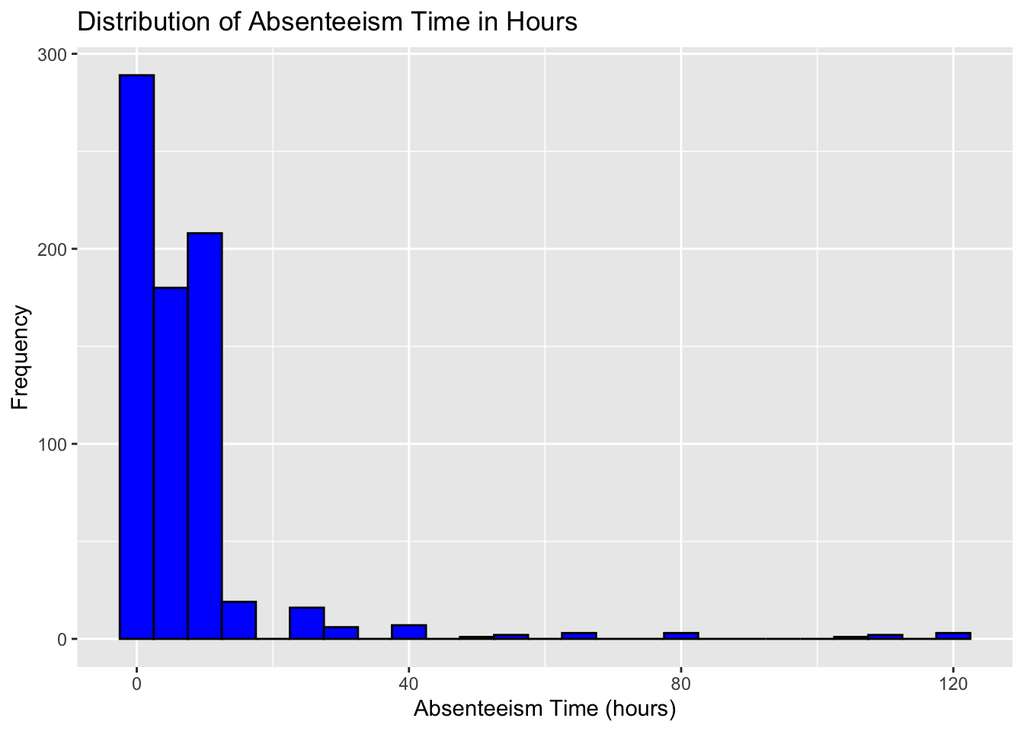

```r
# Distribution of 'Absenteeism time in hours'
ggplot(absent, aes(x = Absenteeism_time_in_hours)) +
  geom_histogram(binwidth = 5, fill = "blue", color = "black") +
  labs(title = "Distribution of Absenteeism Time in Hours", x = "Absenteeism Time (hours)", y = "Frequency")
```

#### Observations for Question 2

```markdown
This section holds the interpretation of the question.
- The histogram shows the frequency distribution of absenteeism time in hours.
- Most employees have low absenteeism time, with fewer instances of high absenteeism.
- There may be some outliers with exceptionally high absenteeism time.
```

### Question 3: Distribution of Ages Among Employees

#### Explanation

Analyzing the age distribution of employees helps to understand the demographic spread within the company. It can also indicate if certain age groups are more prevalent and if age might be a factor influencing absenteeism.

#### Code

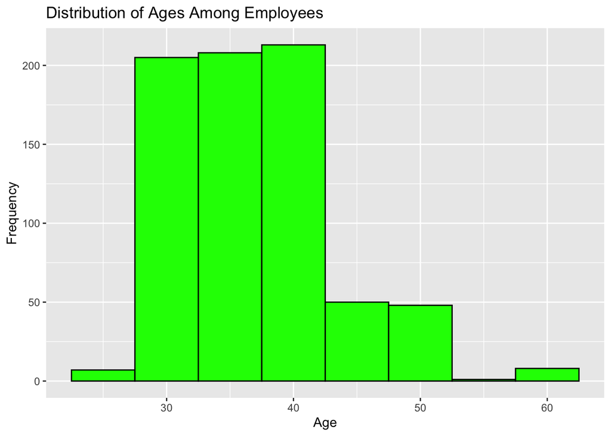

```r
# Distribution of ages among employees
ggplot(absent, aes(x = Age)) +
  geom_histogram(binwidth = 5, fill = "green", color = "black") +
  labs(title = "Distribution of Ages Among Employees", x = "Age", y = "Frequency")
```

#### Observations for Question 3

```markdown
This section holds the interpretation of the question.
- The histogram displays the age distribution of employees.
- The majority of employees fall within a specific age range.
- Certain age groups may be more prevalent, indicating potential age-related trends in absenteeism.
```